# Progetto Streaming Data Management and Time Series Analysis

Federico Manenti 790032

10/09/2020

# Introduzione

In questo progetto si studia una serie temporale riguardante i prezzi del mercato energetico giornaliero dal 01-01-2010 al 31-12-218. L’obiettivo è la previsione degli 11 mesi successivi (01-01-2019 al 31-11-2019) utilizzando tre metodologie diverse: ARIMA, UCM e Reti Neurali.

Per il confronto tra le diverse metodologie la principale misura di errore utilizzata è il $MSE$ perchè è una metrica che pesa molto di più gli errori gravi rispetto a quelli piccoli. Verrà fornito anche il $MAPE$ perchè una misura di valutazione di facile interpretazione umana (l’utilizzo del MAPE è possibile in quanto i dati sono dei prezzi e quindi sempre maggiori di 0).  
Per il confronto interno tra modelli della stessa metodologia invece si utilizzerà per $ARIMA$ l’$AIC$, per $UCM$ e $NN$ si usano $MSE$ e $MAPE$ su train o test set.

Infine i primi sette anni (01-01-2010 al 31-12-2016) sono usati come train e gli ultimi due (01-01-2017 al 31-12-2018) come test.

# Load Libraries

```r
library(dplyr)
library(kableExtra)
library(xts)
library(ggplot2)
library(tidyr)
library(forecast)
library(urca)
library(MLmetrics)
library(KFAS)
```

# Load data

Vengono caricati e mostrati i dati della serie storica relativi al prezzo del mercato energetico dal 1/01/2010 al 31/12/2018.

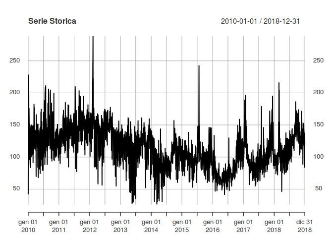

```r
data <- read.csv("time_series_dataset.csv", sep = ";")
data$Data <- as.Date(as.character(data$Data))
y <- data$value
y <- xts(y, as.Date(as.character(data$Data),
                    format = "%Y-%m-%d"))
plot(y, main = "Serie Storica")
```

# ARIMA

Per risolvere il problema di previsione e trovare l’ordine del modello ARIMA si usa la metodologia Box e Jenkins.

## Controllo stazionarità in varianza

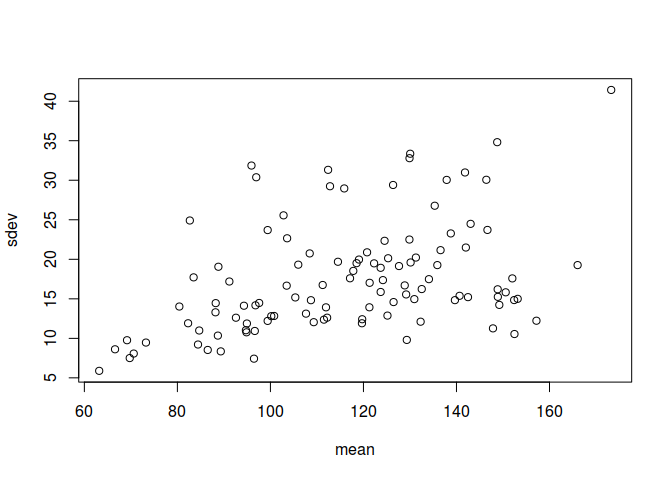

```r
# Caloclo media e sd mensile
mean <- tapply(y, substr(time(y), 1, 7), mean)
sdev <- tapply(y, substr(time(y), 1, 7), sd)
plot(mean, sdev)
```

Non sembra esserci dipendenza tra media e dev standard.

```r
BoxCox.lambda(y)
```

```
## [1] 0.9306309
```

Anche il calcolo ottimale del lambda per la traformazione di box-cox restituisce un numero simile ad 1

## Controllo stazionarietà in media per stagionalità

Sembra esserci una stagionalità ogni 7 giorni quindi si applica la differenza e poi si verifica l’ipotesi.

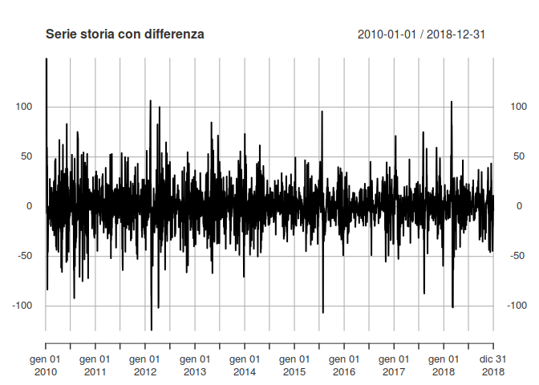

```r
y_diff <- diff(y, 7)

plot(y_diff, main = "Serie storia con differenza")
```

Ora il grafico non mostra più stagionalità come prima, si prova anche l’augmented Dickey-Fulier test come ulteriore conferma.

```r
summary(ur.df(y_diff[!is.na(y_diff)], "drift", 10, "AIC"))
```

```
##
## ###############################################
## # Augmented Dickey-Fuller Test Unit Root Test #
## ###############################################
##
## Test regression drift
##
##
## Call:
## lm(formula = z.diff ~ z.lag.1 + 1 + z.diff.lag)
##
## Residuals:
##     Min      1Q  Median      3Q     Max
## -68.455  -7.937  -0.178   8.350  81.715
##
## Coefficients:
##             Estimate Std. Error t value Pr(>|t|)
## (Intercept) -0.01784    0.28374  -0.063   0.9499
## z.lag.1     -0.57247    0.03276 -17.473  < 2e-16 ***
## z.diff.lag1 -0.03846    0.03184  -1.208   0.2273
## z.diff.lag2  0.02821    0.02970   0.950   0.3423
## z.diff.lag3  0.11340    0.02593   4.374 1.26e-05 ***
## z.diff.lag4  0.13391    0.02533   5.287 1.33e-07 ***
## z.diff.lag5  0.13528    0.02422   5.585 2.52e-08 ***
## z.diff.lag6  0.23244    0.02310  10.063  < 2e-16 ***
## z.diff.lag7 -0.25293    0.02201 -11.493  < 2e-16 ***
## z.diff.lag8 -0.08513    0.02035  -4.183 2.95e-05 ***
## z.diff.lag9 -0.04010    0.01741  -2.303   0.0213 *
## ---
## Signif. codes:  0 '***' 0.001 '**' 0.01 '*' 0.05 '.' 0.1 ' ' 1
##
## Residual standard error: 16.22 on 3258 degrees of freedom
## Multiple R-squared:  0.4675, Adjusted R-squared:  0.4659
## F-statistic:   286 on 10 and 3258 DF,  p-value: < 2.2e-16
##
##
## Value of test-statistic is: -17.4729 152.6506
##
## Critical values for test statistics:
##       1pct  5pct 10pct
## tau2 -3.43 -2.86 -2.57
## phi1  6.43  4.59  3.78
```

Visto che il valore del test: -17.4728557 è minore del valore critico -2.86 conferma che il processo ora è stazionario.

## Controllo Stazionarietà in media (TREND)

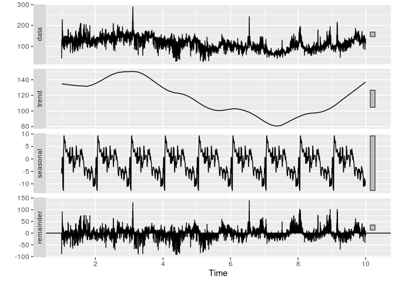

```r
stl(ts(as.numeric(y), frequency = 365.25), s.window = "periodic", robust = T) %>%
  autoplot()
```

Sembra esserci un piccolo trend, per ora però non viene considerato.

## Split Train e Test

```r
y_train <- y
y_test <- y
y_train["2017-01-01/2018-12-31"] <- NA
y_test["2010-01-01/2016-12-31"] <- NA
plot(y_train, main="Time Series")
```

```r
lines(y_test, col = "red")
```

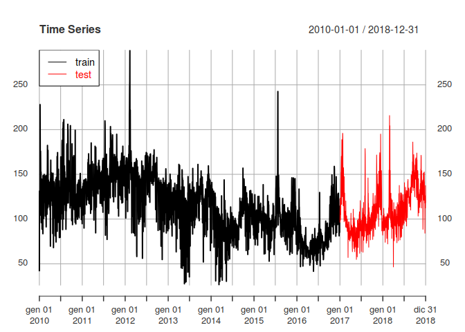

```r
addLegend(legend.loc = "topleft", legend.names=c("train", "test"),
          col=c("black", "red"), lty=1, bg="white",
          bty = 1, text.col = c("black", "red"))
```

## Primo modello

Si studiano i grafici ACF e PACF della serie ritardata.

```r
 ggtsdisplay(diff(y_train, 7), lag.max = 60,
             main = "Residui serie temporale con differenzazione")
```

[figure not shown]

Dai grafici ACF e PACF della serie con differenzazione sembra esserci un $SARMA(1)[7]$. Il primo modello provato (sulla serie base) è quinidi $ARIMA(0,0,0)(1,1,1)[7]$

```r
mod1 <- Arima(y_train, c(0,0,0), list(order=c(1,1,1), period = 7), lambda = "auto")
mod1
```

```
## Series: y_train
## ARIMA(0,0,0)(1,1,1)[7]
## Box Cox transformation: lambda= 0.9878974
##
## Coefficients:
##         sar1     sma1
##       0.2471  -0.8018
## s.e.  0.0316   0.0212
##
## sigma^2 estimated as 274.8:  log likelihood=-10780.12
## AIC=21566.23   AICc=21566.24   BIC=21583.76
```

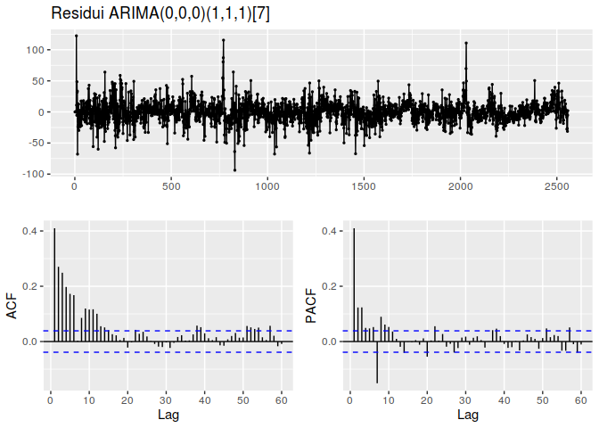

```r
ggtsdisplay(mod1$residuals, lag.max = 60, main = "Residui ARIMA(0,0,0)(1,1,1)[7]")
```

Dagli ACF e PACF dei residui del primo modello potrebbe esserci ancora presente un MA(6) e un AR(6) visto i primi 6 lag in ACF e PACF, sembrano però esserci anche delle anomalie che non permettono di esere sicuri sull’ordine di $p$ e $q$.

Inoltre, come accennato precedentemente, potrebbe esserci anche un trend e quindi un integrazione non stagionale per cui si troverà il miglior modello $ARMA(p,q)$ e poi si proverà ad inserire l’integrazione.

```r
# Questo chunk non viene eseguito nel report perchè estremamente lungo da calcolare

best_mod <- Arima(y_train, c(0,0,0), list(order=c(1,1,1), period=7),
                  lambda = "auto")
best_loglik <- best_mod$loglik
best_aic <- best_mod$aic

for (i in 1:12){
    for (j in 1:12){
      tryCatch({
            temp_mod <- Arima(y_train, c(i,0,j), list(order=c(1,1,1), period=7),
                          lambda = "auto")
            temp_mod_loglik <- temp_mod$loglik
            temp_mod_aic <- temp_mod$aic
            if (best_aic > temp_mod$aic){
                best_mod <- temp_mod
                best_aic <- temp_mod$aic
            }
            if (best_loglik < temp_mod$loglik){
              best_loglik <- temp_mod$loglik
            }
            }, error=function(e){temp_mod_aic <- 99999
            temp_mod_loglik <- 99999})

        print(paste0("AR-",i," MA-",j,
                     " -- AIC:",temp_mod_aic, " --BEST_AIC:",best_aic,
                     " -- loglik:",temp_mod_loglik, " --BEST_loglik:", best_loglik),
              flush=TRUE)
    }
}
```

Il modello con AIC minore è $ARIMA(3,0,4)(1,1,1)[7]$.

```r
# Tenendo conto di AIC

best_mod <- Arima(y_train, c(3,0,4), list(order=c(1,1,1), period = 7),
                  lambda = "auto")
best_mod
```

```
## Series: y_train
## ARIMA(3,0,4)(1,1,1)[7]
## Box Cox transformation: lambda= 0.9878974
##
## Coefficients:
##          ar1      ar2     ar3      ma1     ma2      ma3      ma4    sar1
##       0.9541  -0.9375  0.9311  -0.5683  0.7835  -0.5673  -0.1908  0.0792
## s.e.  0.0143   0.0185  0.0173   0.0244  0.0256   0.0234   0.0215  0.0223
##          sma1
##       -0.9662
## s.e.   0.0069
##
## sigma^2 estimated as 197.2:  log likelihood=-10359.13
## AIC=20738.26   AICc=20738.35   BIC=20796.7
```

Si aggiunge l’integrazione non stagionale al modello appena trovato e si confrontano i risultati per decretare il migliore.

```r
best_mod_int <- Arima(y_train, c(3,1,4),
                      list(order=c(1,1,1), period = 7), lambda = "auto")
best_mod_int
```

[output not shown]

```
##           ar1      ar2      ar3      ma1     ma2      ma3      ma4    sar1
##       -0.0233  -0.9471  -0.0049  -0.5837  0.7567  -0.5773  -0.2123  0.0794
## s.e.      NaN   0.0015      NaN   0.0065  0.0046   0.0089      NaN     NaN
##          sma1
##       -0.9741
## s.e.   0.0039
##
## sigma^2 estimated as 199.2:  log likelihood=-10370.75
## AIC=20761.5   AICc=20761.58   BIC=20819.93
```

Confrontando le AIC risulta migliore il modello senza integrazione.

Si studiano ora i residui del modello.

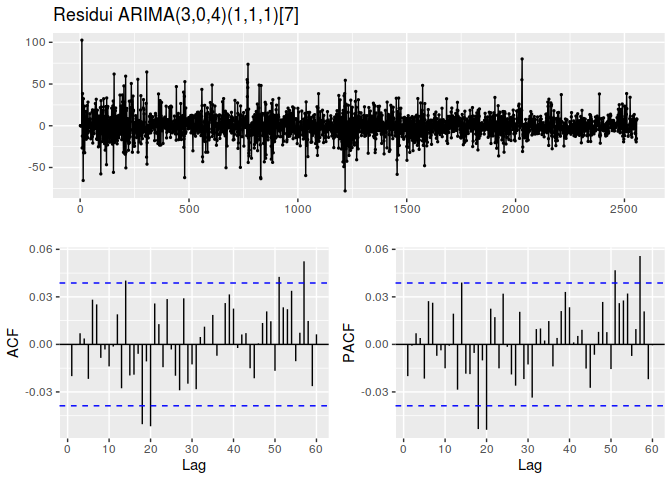

```r
ggtsdisplay(best_mod$residuals, lag.max = 60,
            main = "Residui ARIMA(3,0,4)(1,1,1)[7]")
```

Dagli ACF e PACF sembra che i residui siano rientrati tranne alcuni, per confermare che siano un White Noise si usa il test di Ljung-Box.

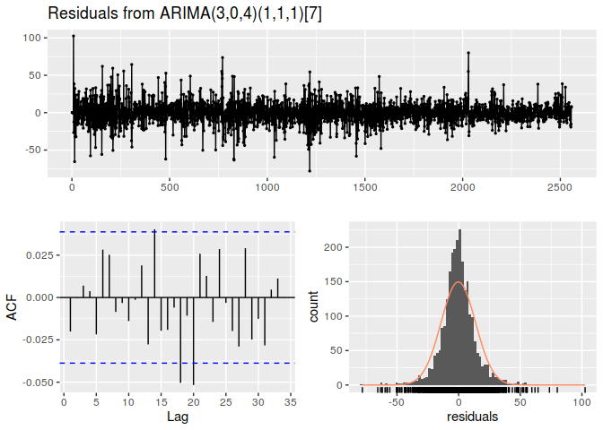

```
##
##  Ljung-Box test
##
## data:  Residuals from ARIMA(3,0,4)(1,1,1)[7]
## Q* = 7.7169, df = 3, p-value = 0.05224
##
## Model df: 9.   Total lags used: 12
```

```r
checkresiduals(best_mod)
```

```r
plot(y_train, main = "Train serie tempolare con fit")
```

```r
lines(xts(best_mod$fitted, as.Date(time(y_train))), col = "red")
```

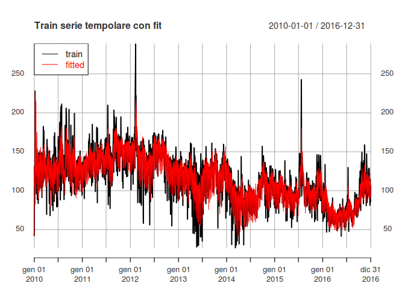

```r
addLegend(legend.loc = "topleft", legend.names=c("train", "fitted"),
          col=c("black", "red"), lty=1,
          bg="white", bty = 1, text.col = c("black", "red"))
```

Il modello sembra funzionare bene sul train set.

### Prova previsioni

Nel mercato energetico solitamente è importante la previsione un passo in avanti, la consegna dell’esame però chiede la previsione dei primi 11 mesi del 2019, non avendo a disposizione i dati reali non è possibile procedere in questo modo, ma per valutare la bontà delle previsioni si utilizzerà quindi una previsione con orizzonte temporale 334.

```r
prev <- c()
for (i in (0:(length(y_test)-1))) {

  prev <- append(prev, forecast(Arima(y[1:(length(y_train) + i)],
                                      model = best_mod), h = 1)$mean)
}


plot(y_test, main = "Test serie temporale")
```

```r
lines(xts(prev, time(y_test)), col = "red")
```

```r
lines(xts(forecast(best_mod, length(y_test))$mean, time(y_test)), col = "blue")
```

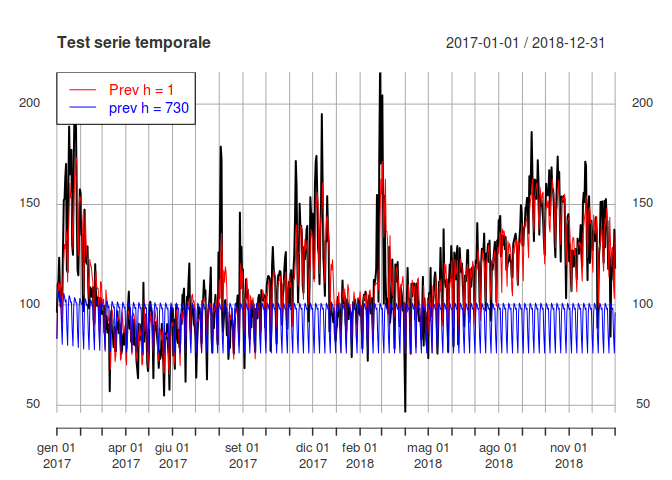

```r
addLegend(legend.loc = "topleft", legend.names=c("Prev h = 1", "prev h = 730"),
          col=c("red", "blue"), lty=1, bg="white",
          bty = 1, text.col = c("red", "blue"))
```

Come si vede dal grafico la previsione rolling 1 passo in avanti si adatta bene alla serie storica, ma quando si tenta di prevedere tutto il test set in un unica volta si ottiene un pessimo risultato.

Si cerca dunque di modifiare il modello inserendo dei regressori esterni (sinusoidali) per risolvere la multistagionalità che risulta evidente nella serie storica. Il numero ideale di regressori esterni sinusoidali è scelto tramite la valutazione del modello su test set, ovvero il modello che raggiunge il valore di MSE più basso.

```r
# Questo chunk non viene eseguito nel report perchè estremamente lungo da calcolare

total_MSE <- c()
total_MAPE <- c()
for (j in 1:30){
  freq <- outer(1:nrow(data), 1:j)*2*pi/365.25

  cs   <- cos(freq)
  colnames(cs) <- paste("cos", 1:j)
  si   <- sin(freq)
  colnames(si) <- paste("cos", 1:j)
  sin_reg <- as.matrix(cbind(cs,si))


  best_mod_reg <- Arima(y_train, c(3,0,4), list(order=c(1,1,1), period=7),
                        xreg=sin_reg[1:(length(y_train)),], lambda = "auto")


  temp_forecast <- forecast(best_mod_reg, h=334,
                            xreg=sin_reg[(length(y_train)):(length(y_train)+333),])

  score_MAPE <- c(mean(abs(as.numeric(temp_forecast$mean) -
                             as.numeric(y_test[1:334]))/
                         as.numeric(y_test[1:334])))
  score_MSE <- c(sum((as.numeric(temp_forecast$mean) -
                        as.numeric(y_test[1:334]))^2)/334)

      for (i in 1:(length(y_test) - 334)){
              temp_mod <- Arima(append(y_train[i:length(y_train)],y_test[1:i]),
                                model=best_mod_reg,
                                xreg=sin_reg[i:(length(y_train)+i),])

              temp_forecast <- forecast(temp_mod, h=334,
                                        xreg=sin_reg[(length(y_train)+i+1):
                                                     (length(y_train)+i+334),])$mean

              score_MAPE <- append(score_MAPE, mean(abs(as.numeric(temp_forecast) -
                                                as.numeric(y_test[(i+1):(i+334)]))/
                                                  as.numeric(y_test[(i+1):(i+334)])))

              score_MSE <- append(score_MSE,
                                  sum((as.numeric(temp_forecast) -
                                         as.numeric(y_test[(i+1):(i+334)]))^2)/334)
          }

  print(paste0("ARIMA MAPE medio: ", mean(score_MAPE)*100))
  print(paste0("ARIMA MSE medio: ", mean(score_MSE)))
  arima_MAPE <- mean(score_MAPE)*100
  arima_MSE <- mean(score_MSE)
  total_MAPE <- append(total_MAPE, arima_MAPE)
  total_MSE <- append(total_MSE, arima_MSE)
}
```

Il numero ideale di armoniche è 5.

```r
freq <- outer(1:nrow(data), 1:5)*2*pi/365.25

cs   <- cos(freq)
colnames(cs) <- paste("cos", 1:5)
si   <- sin(freq)
colnames(si) <- paste("sin", 1:5)
sin_reg <- as.matrix(cbind(cs,si))


best_mod_reg <- Arima(y_train, c(3,0,4), list(order=c(1,1,1), period=7),
                      xreg=sin_reg[1:(length(y_train)),], lambda = "auto")

best_mod_reg
```

```
## Series: y_train
## Regression with ARIMA(3,0,4)(1,1,1)[7] errors
## Box Cox transformation: lambda= 0.9878974
##
## Coefficients:
##          ar1      ar2     ar3      ma1     ma2      ma3      ma4    sar1
##       0.9470  -0.9352  0.9224  -0.5703  0.7767  -0.5682  -0.1962  0.0729
## s.e.  0.0159   0.0199  0.0185   0.0254  0.0271   0.0243   0.0222  0.0224
##          sma1   cos 1   cos 2    cos 3   cos 4    cos 5   sin 1   sin 2
##       -0.9623  3.6444  0.9135  -1.1701  1.4324  -2.7010  -8.272  2.5080
## s.e.   0.0077  2.5768  1.9822   1.5679  1.2866   1.0935   2.635  2.0046
##         sin 3   sin 4    sin 5
##       -0.5512  0.1637  -2.4228
## s.e.   1.5793  1.2935   1.0982
##
## sigma^2 estimated as 196.2:  log likelihood=-10347.73
## AIC=20735.46   AICc=20735.79   BIC=20852.34
```

```r
plot(y_test, main = "Previsioni test con orizonte temporale 730")
```

```r
lines(xts(forecast(best_mod, length(y_test))$mean, time(y_test)), col = "red")
```

```r
lines(xts(forecast(best_mod_reg, length(y_test),
                   xreg=sin_reg[(length(y_train)):(length(y_train)+729),])$mean,
          time(y_test)), col = "blue")
```

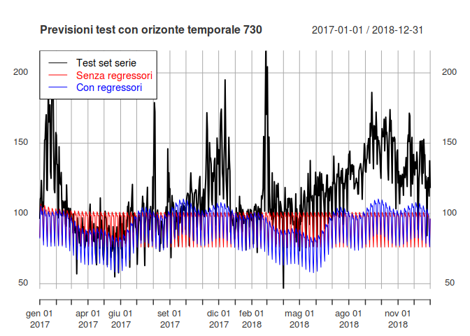

```r
addLegend(legend.loc = "topleft",
          legend.names=c("Test set serie", "Senza regressori", "Con regressori"),
          col=c("black", "red", "blue"), lty=1,
          bg="white", bty = 1, text.col = c("black", "red", "blue"))
```

Come si può notare dal grafico grazie ai regressori la performance della previsione migliora, ma non è ancora perfetta, un’altra idea per aumentare la precisione è utilizzare variabili dummy per le festività.

Non conoscendo però il paese di origine della serie temporale e quindi le feste da utilizzare non si può essere sicuri di migliorare la previsione, in effetti da una prova effettuata utilizzando solo le festività: il modello peggiora le previsioni.

Il codice è presente, ma non verrà quindi eseguito.

## Prova vacanze

```r
ferragosto <- as.Date(paste0(2010:2019, "-08-15"))

fine_anno <- as.Date(paste0(2010:2019, "-12-31"))

capodanno <- as.Date(paste0(2010:2019, "-01-01"))

natale <- as.Date(paste0(2010:2019, "-12-25"))

pasqua <- as.Date(Easter(2010:2019))


data.frame(Data=data$Data) %>%
    mutate(Christmas = as.numeric(Data %in% natale)) %>%
    mutate(new_year = as.numeric(Data %in% capodanno)) %>%
    mutate(end_year = as.numeric(Data %in% fine_anno)) %>%
    mutate(Easter = as.numeric(Data %in% pasqua)) %>%
    mutate(Ferragosto = as.numeric(Data %in% ferragosto)) %>%
    select(-starts_with("Data")) %>%
    cbind(sin_reg) %>%
    as.matrix() -> sin_reg


best_mod_vac <- Arima(y_train, c(3,0,4), list(order=c(1,1,1), period=7),
                      xreg=sin_reg[1:(length(y_train)),], lambda = "auto")
best_mod_vac
```

## Previsioni modello migliore

Come già accennato le previsioni vengono effettuate 334 passi in avanti e come metriche vengono usate MSE perchè pesa di più gli errori gravi rispetto a quelli piccoli e MAPE perchè di facile interpretazione umana. Il modello utilizzato è l’$ARIMA(3,0,4)(1,1,1)[7]$ con i regressori sinusoidali.

```r
temp_forecast <- forecast(best_mod_reg, h=334,
                          xreg=sin_reg[(length(y_train)):(length(y_train)+333),])

score_MAPE <- c(mean(abs(as.numeric(temp_forecast$mean) -
                           as.numeric(y_test[1:334]))/as.numeric(y_test[1:334])))

score_MSE <- c(sum((as.numeric(temp_forecast$mean) -
                      as.numeric(y_test[1:334]))^2)/334)

for (i in 1:(length(y_test) - 334)){
    temp_mod <- Arima(append(y_train[i:length(y_train)],y_test[1:i]),
                      model=best_mod_reg, xreg=sin_reg[i:(length(y_train)+i),])

    temp_forecast <- forecast(temp_mod, h=334,
                              xreg=sin_reg[(length(y_train)+i+1):
                                             (length(y_train)+i+334),])$mean

    score_MAPE <- append(score_MAPE, mean(abs(as.numeric(temp_forecast) -
                                      as.numeric(y_test[(i+1):(i+334)]))/
                                        as.numeric(y_test[(i+1):(i+334)])))
    score_MSE <- append(score_MSE,
                        sum((as.numeric(temp_forecast) -
                               as.numeric(y_test[(i+1):(i+334)]))^2)/334)
}
```

```r
cat(paste0("ARIMA MAPE train set: ",
           mean(abs(best_mod_reg$fitted - as.numeric(y_train)) /
                  as.numeric(y_train))*100,
           "\n", "ARIMA MSE train set: ",
           sum(((best_mod_reg$fitted-as.numeric(y_train))^2) /
                 length(y_train))))
```

```
## ARIMA MAPE train set: 9.71659199462841
## ARIMA MSE train set: 218.096675587402
```

```r
arima_MAPE <- mean(score_MAPE)*100
arima_MSE <- mean(score_MSE)
cat(paste0("ARIMA MAPE medio test set: ", mean(score_MAPE)*100,
           "\n","ARIMA MSE medio test set: ", mean(score_MSE)))
```

```
## ARIMA MAPE medio test set: 14.1728623922858
## ARIMA MSE medio test set: 540.295863112492
```

# UCM

Per quanto riguarda il modello $UCM$ vengono usate le considerazioni effettuate per $ARIMA$ e quindi è proposto un modello con LLT, una componente stagionale (dummy) settimanale e una annua (trigonometrica, di cui si prendono le prime 5 armoniche) entrambe stocastiche. Tutti i modelli UCM vengono implementati in forma State Space sfruttando la libreria KFAS.

## Primo modello (LLT + stag)

```r
ucm_model <- SSModel(y_train ~ SSMtrend(2, list(NA, NA)) +
                       SSMseasonal(7, NA, "dummy") +
                       SSMseasonal(365, NA, "trig", harmonics = 1:5),
                     H = NA)
# Si sistemano le condizioni iniziali per evitare diffusione
vary <- var(y_train)
ucm_model$P1inf <- ucm_model$P1inf * 0
ucm_model$a1[1] <- mean(y_train)
diag(ucm_model$P1) <- vary


# Si fissano i valori iniziali delle varianze
pars <- numeric(5)
pars[1] <- log(vary/10)       # Level
pars[2] <- log(vary/10)       # Slope
pars[3] <- log(vary/100)      # Seasonal dummy
pars[4] <- log(vary/100)      # Seasonal trig
pars[5] <- log(vary/10)       # Obs error


  # Funzione di update
updt <- function(pars, model){
    model$Q[1, 1, 1] <- exp(pars[1])
    model$Q[2, 2, 1] <- exp(pars[2])
    model$Q[3, 3, 1] <- exp(pars[3])
    diag(model$Q[4:13, 4:13, 1]) <- exp(pars[4])
    model$H[1, 1, 1] <- exp(pars[5])
    model
}

ucm_fit <- fitSSM(ucm_model, pars, updt)

ucm_fit$optim.out$convergence
```

```
## [1] 0
```

Ha raggiunto la convergenza.

```r
smo <- KFS(ucm_fit$model, filtering = "signal", smoothing = NULL )

plot(y_train, main = "Train serie temporale fittata con UCM")
```

```r
lines(xts(smo$m[,1], time(y_train)), col = "red")
```

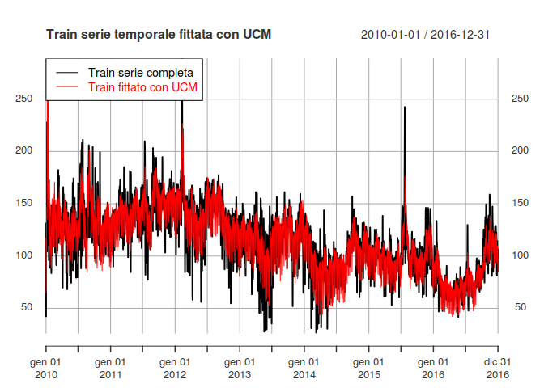

```r
addLegend(legend.loc = "topleft",
          legend.names=c("Train serie completa", "Train fittato con UCM"),
          col=c("black", "red"), lty=1, bg="white",
          bty = 1, text.col = c("black", "red"))
```

Si calcola ora MSE e MAPE sul train set.

```r
cat(paste0("MAPE UCM su train set: ",
           mean(abs(y_train - as.numeric(smo$m))/y_train)*100,
           "\n", "MSE UCM su train set: ",
           sum((y_train - as.numeric(smo$m))^2)/length(y_train)))
```

```
## MAPE UCM su train set: 10.4152986727712
## MSE UCM su train set: 257.494943551962
```

## Secondo modello (IRW)

La seconda prova avviene con Integrated Random Walk e le stesse componenti stagionali precedenti.

```r
ucm_mod1 <- SSModel(y_train ~ SSMtrend(2, list(0,NA)) +
                      SSMseasonal(7, NA, "dummy") +
                      SSMseasonal(365, NA, "trig",
                                  harmonics = 1:5),
                H = NA)
# Si sistemano le condizioni iniziali per evitare diffusione
ucm_mod1$P1inf <- ucm_mod1$P1inf * 0
ucm_mod1$a1[1] <- mean(y_train)
diag(ucm_mod1$P1) <- vary



# Si fissano i valori iniziali delle varianze
pars <- numeric(5)
pars[1] <- 0                  # Level
pars[2] <- log(vary/10)       # Slope
pars[3] <- log(vary/100)      # Seasonal dummy
pars[4] <- log(vary/100)      # Seasonal trig
pars[5] <- log(vary/10)       # Obs error

#funzione per fitSSM
updt1 <- function(pars, model){
    model$Q[1, 1, 1] <- exp(pars[1])
    model$Q[2, 2, 1] <- exp(pars[2])
    model$Q[3, 3, 1] <- exp(pars[3])
    diag(model$Q[4:13, 4:13, 1]) <- exp(pars[4])
    model$H[1, 1, 1] <- exp(pars[5])
    model
}

ucm_fit1 <- fitSSM(ucm_mod1, pars, updt1)
print(ucm_fit1$optim.out$convergence)
```

```
## [1] 0
```

Ha raggiunto la convergenza.

```r
smo1 <- KFS(ucm_fit1$model, filtering = "signal", smoothing = NULL )
cat(paste0("MAPE UCM su train set: ", mean(abs(y_train -
                                                 as.numeric(smo1$m))/y_train)*100,
           "\n", "MSE UCM su train set: ", sum((y_train - as.numeric(smo1$m))^2) /
             length(y_train)))
```

```
## MAPE UCM su train set: 10.6786648931455
## MSE UCM su train set: 262.237727220608
```

Il modello con LLT risulta migliore sia considerando MSE che MAPE.

## Terzo modello (RW)

Il terzo modello utilizza un Random Walk e le due solite componenti stagionali.

```r
ucm_mod2 <- SSModel(y_train ~ SSMtrend(1, NA) +
                      SSMseasonal(7, NA, "dummy") +
                      SSMseasonal(365, NA, "trig",
                                  harmonics = 1:5),
                H = NA)
# Si sistemano le condizioni iniziali per evitare diffusione
ucm_mod2$P1inf <- ucm_mod2$P1inf * 0
ucm_mod2$a1[1] <- mean(y_train)
diag(ucm_mod2$P1) <- vary



# Si fissano i valori iniziali delle varianze
pars <- numeric(5)
pars[1] <- log(vary/10)       # Level
pars[2] <- log(vary/100)      # Seasonal dummy
pars[3] <- log(vary/100)      # Seasonal trig
pars[4] <- log(vary/10)       # Obs error

#funzione per fitSSM
updt2 <- function(pars, model){
    model$Q[1, 1, 1] <- exp(pars[1])
    model$Q[2, 2, 1] <- exp(pars[2])
    diag(model$Q[3:12, 3:12, 1]) <- exp(pars[4])
    model$H[1, 1, 1] <- exp(pars[5])
    model
}

ucm_fit2 <- fitSSM(ucm_mod2, pars, updt2)
print(ucm_fit1$optim.out$convergence)
```

```
## [1] 0
```

```r
smo2 <- KFS(ucm_fit2$model, filtering = "signal", smoothing = NULL )
cat(paste0("MAPE UCM su train set: ",
           mean(abs(y_train - as.numeric(smo2$m))/y_train)*100,
           "\n", "MSE UCM su train set: ",
           sum((y_train - as.numeric(smo2$m))^2)/length(y_train)))
```

```
## MAPE UCM su train set: 10.3862041943688
## MSE UCM su train set: 257.690826581511
```

Il modello con LLC e quello con solo RW hanno dei valori molto simili sul train set, per scegliere il migliore quindi vengono utilizzati entrambi per le previsioni con orizzonte temporale 334 sul test set e verrà selezionato il modello con le performance migliori.

## Previsioni

Per valutare i due modelli, come per Arima, si utilizza un orizzonte temporale pari a 334 giorni.

### LLT

```r
data <- c(rep(NA, 334))
temp_mod <- SSModel(data ~  SSMtrend(2, list(ucm_fit$model$Q[1,1,1],
                                             ucm_fit$model$Q[2,2,1])) +
                      SSMseasonal(7, ucm_fit$model$Q[3,3,1], "dummy") +
                      SSMseasonal(365, ucm_fit$model$Q[4, 4, 1], "trig",
                              harmonics = 1:5),
                    H = ucm_fit$model$H)

ucm_pred <- predict(ucm_fit$model, newdata=temp_mod)
test <- as.numeric(y_test)[1:334]

score_MAPE <- c(mean(abs(ucm_pred - test)/test))
score_MSE <- c(sum((ucm_pred-test)^2)/334)

for (i in 1:(length(y_test) - 334)){
    data <- c(as.numeric(y_test[1:i]), rep(NA, 334))

    temp_mod <- SSModel(data ~ SSMtrend(2, list(ucm_fit$model$Q[1,1,1],
                                                ucm_fit$model$Q[2,2,1])) +
                      SSMseasonal(7, ucm_fit$model$Q[3,3,1], "dummy") +
                      SSMseasonal(365, ucm_fit$model$Q[4, 4, 1], "trig",
                                  harmonics = 1:5),
                    H = ucm_fit$model$H)

    ucm_pred <- predict(ucm_fit$model, newdata=temp_mod)[(i+1):(i+334)]
    test <- as.numeric(y_test)[(i+1):(i+334)]
    score_MAPE <- append(score_MAPE, mean(abs(ucm_pred - test)/test))
    score_MSE <- append(score_MSE, sum((ucm_pred-test)^2)/334)
}

ucm_MAPE <- mean(score_MAPE)*100
ucm_MSE <- mean(score_MSE)

cat(paste0("UCM MAPE medio: ", mean(score_MAPE)*100,
           "\n","UCM MSE medio: ", mean(score_MSE)))
```

```
## UCM MAPE medio: 19.0288372605154
## UCM MSE medio: 819.110732516009
```

### RW

```r
data <- c(rep(NA, 334))
temp_mod <- SSModel(data ~  SSMtrend(1, ucm_fit2$model$Q[1,1,1]) +
                      SSMseasonal(7, ucm_fit2$model$Q[2,2,1], "dummy") +
                      SSMseasonal(365, ucm_fit2$model$Q[3, 3, 1], "trig",
                              harmonics = 1:5),
                    H = ucm_fit2$model$H)

ucm_pred <- predict(ucm_fit2$model, newdata=temp_mod)
test <- as.numeric(y_test)[1:334]

score_MAPE <- c(mean(abs(ucm_pred - test)/test))
score_MSE <- c(sum((ucm_pred-test)^2)/334)

for (i in 1:(length(y_test) - 334)){
    data <- c(as.numeric(y_test[1:i]), rep(NA, 334))

    temp_mod <- SSModel(data ~ SSMtrend(1, ucm_fit2$model$Q[1, 1, 1]) +
                      SSMseasonal(7, ucm_fit2$model$Q[2, 2, 1], "dummy") +
                      SSMseasonal(365, ucm_fit2$model$Q[3, 3, 1], "trig",
                                  harmonics = 1:5),
                    H = ucm_fit2$model$H)

    ucm_pred <- predict(ucm_fit2$model, newdata=temp_mod)[(i+1):(i+334)]
    test <- as.numeric(y_test)[(i+1):(i+334)]
    score_MAPE <- append(score_MAPE, mean(abs(ucm_pred - test)/test))
    score_MSE <- append(score_MSE, sum((ucm_pred-test)^2)/334)
}


ucm_MAPE <- mean(score_MAPE)*100
ucm_MSE <- mean(score_MSE)

cat(paste0("UCM MAPE medio: ", mean(score_MAPE)*100,
           "\n","UCM MSE medio: ", mean(score_MSE)))
```

```
## UCM MAPE medio: 18.5360875004533
## UCM MSE medio: 778.907908273407
```

Il modello che raggunge performance più soddisfacenti è quello con il Random Walk.

Ricapitolando le performance del modello UCM migliore (RW) sul train e test set sono.

```r
cat(paste0("UCM MAPE train set: ",
           mean(abs(y_train - as.numeric(smo2$m))/y_train)*100,
           "\n", "UCM MSE train set: ",
           sum((y_train - as.numeric(smo2$m))^2)/length(y_train)))
```

```
## UCM MAPE train set: 10.3862041943688
## UCM MSE train set: 257.690826581511
```

```r
cat(paste0("UCM MAPE medio test set: ", ucm_MAPE,
           "\n","UCM MSE medio test set: ", ucm_MSE))
```

```
## UCM MAPE medio test set: 18.5360875004533
## UCM MSE medio test set: 778.907908273407
```

Le previsioni one-shot sul test set sono mostrate in figura.

```r
plot(y_test, main="Previsioni modello UCM (RW) su test set")
```

```r
lines(xts(predict(ucm_fit2$model, n.ahead = 730)[,1], time(y_test)), col = "red")
```

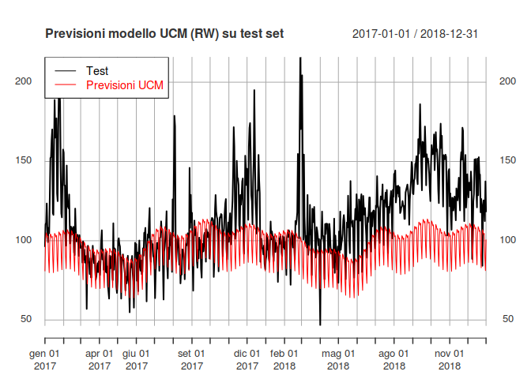

```r
addLegend(legend.loc = "topleft", legend.names=c("Test", "Previsioni UCM"),
          col=c("black", "red"), lty=1, bg="white",
          bty = 1, text.col = c("black", "red"))
```

# Reti Neurali

Le reti neurali provate sono state implementate usando python, il codice si trova nel relativo notebook.

Per prima cosa i dati sono stati standardizzati per ottenere media 0 e deviazione standard pari a 1, la “maschera” è stata ottenuta dal train set. Successivamente è stato modificato il dataset nel forma adatta alle reti neurali ed è stata scelta una finestra $time\_step$ (i dati che può guardare il modello in dietro) di 2 anni e una finestra $prev\_step$ (i dati che deve prevedere il modello) di 334 giorni. La prima è una scelta arbitraria e due anni sono un buon compromesso tra numero di dati e complessità computazionale, la seconda è obbligata dallo scopo del progetto.

L’idea per trovare l’architettura migliore consiste nell’effettuare due prove di RNN molto semplici composte da un layer di input (in un caso LSTM e nell’altro GRU) e uno di output, confrontare il loro risultato e poi utilizzare AutoML per trovare architettura e iperparametri ottimali di una delle due.

Dalle analisi preliminari sembra che LSTM performi meglio rispetto a GRU per questo task, ci si concentra dunque su quell’architettura.  
Il processo di AutoMl permette di ottimizzare gli iperparametri che in questo caso sono:

- Numero layers LSTM
- Numero layers Dense
- Numero neuroni layers LSTM
- Numero neuroni layers Dense
- Learning rate
- Batch size

Come risultato del processo è risultata una rete così composta:

1. LSTM(tanh) (layer input)
2. LSTM(tanh)
3. Dense(relu)
4. Dense(relu)
5. Dense(linear) (layer output)

Nel processo di training è stata usata la callback $early$ $stopping$ con patience 2, il numero di epoche quindi è stato fissato ad un numero alto per far stoppare il processo di apprendimento in maniera automatica. La metrica obiettivo da minimizzare durante AutoML è il $MSE$, usando però la libreria pyGPGO che permette solo massimizzazioni di funzioni black box, la funzione utilizzata come valutazione del modello restituisce l’inverso del $MSE$ che alla fine verà nuovamente convertito nella forma corretta. La funzione di acquisizione utilizzata è l’$Expected$ $Improvement$ e il modello surrogato il random forest in quanto alcuni iperparametri sono valori interi.

In tutte le prove è stato utilizzato l’ottimizzatore $Adam$ e come loss il $MSE$.

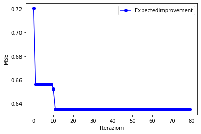

Best seen AutoML

I risultati ottenuti dal modello dopo il processo di AutoML sono i seguenti:

```r
cat(paste0("NN MAPE train set: 20.41811823442015",
           "\n", "NN MSE train set: 572.547001927623"))
```

```
## NN MAPE train set: 20.41811823442015
## NN MSE train set: 572.547001927623
```

```r
cat(paste0("NN MAPE test set: 18.3266778269870",
           "\n", "NN MSE test set: 815.4316568336255"))
```

```
## NN MAPE test set: 18.3266778269870
## NN MSE test set: 815.4316568336255
```

Stranamente si nota che il MAPE sul train set è più alto di quello ottenuto sul test set.

# Conclusioni

I risultati finali delle metodologie usate sono:

Confronto risultati metodologie

| Model | Arima |  | UCM |  | NN |  |
| --- | --- | --- | --- | --- | --- | --- |
| Metrica | MSE | MAPE (%) | MSE | MAPE (%) | MSE | MAPE (%) |
| Train | 218.10 | 9.72 | 257.70 | 10.39 | 572.55 | 20.42 |
| Test | 540.30 | 14.17 | 778.91 | 18.54 | 815.43 | 18.33 |

Per le previsioni finali: dal 01/01/2019 al 31/11/2019 i modelli $ARIMA$ e $UCM$ verranno fittati non solo sul train, ma su tutti i dati disponibili. Per la rete neurale invece il modello migliore viene allenato altre 25 epoche sui dati di test così da conferirgli maggior importanza essendo i dati più recenti disponibili.

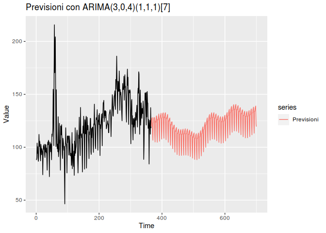

```r
# ARIMA


freq <- outer(1:(length(y)+334), 1:5)*2*pi/365.25

cs   <- cos(freq)
colnames(cs) <- paste("cos", 1:5)
si   <- sin(freq)
colnames(si) <- paste("sin", 1:5)
sin_reg <- as.matrix(cbind(cs,si))


mod_arima <- Arima(y, c(3,0,4), list(order=c(1,1,1), period=7),
                   xreg=sin_reg[1:(length(y)),], lambda = "auto")

pred_arima <- forecast(mod_arima, h = 334,
                       xreg = sin_reg[(length(y)+1):(length(y)+334),])


autoplot(ts(y["2018-01-01/"]), main = "Previsioni con ARIMA(3,0,4)(1,1,1)[7]") +
  autolayer(ts(pred_arima$mean, start = 366, end = 366+334),
            series = "Previsioni") +
  ylab("Value")
```

```r
# UCM

mod_ucm <- SSModel(y ~ SSMtrend(1, NA) +
                             SSMseasonal(7, NA, "dummy") +
                             SSMseasonal(365, NA, "trig",
                                         harmonics = 1:5),
                   H = NA)
# Si sistemano le condizioni iniziali per evitare diffusione
vary <- var(y)
mod_ucm$P1inf <- mod_ucm$P1inf * 0
mod_ucm$a1[1] <- mean(y)
diag(mod_ucm$P1) <- vary



# Si fissano i valori iniziali delle varianze
pars <- numeric(5)
pars[1] <- log(vary/10)       # Level
pars[2] <- log(vary/100)      # Seasonal dummy
pars[3] <- log(vary/100)      # Seasonal trig
pars[4] <- log(vary/10)       # Obs error

#funzione per fitSSM
updt <- function(pars, model){
    model$Q[1, 1, 1] <- exp(pars[1])
    model$Q[2, 2, 1] <- exp(pars[2])
    diag(model$Q[3:12, 3:12, 1]) <- exp(pars[4])
    model$H[1, 1, 1] <- exp(pars[5])
    model
}

ucm_fit <- fitSSM(mod_ucm, pars, updt)
print(ucm_fit1$optim.out$convergence)
```

```
## [1] 0
```

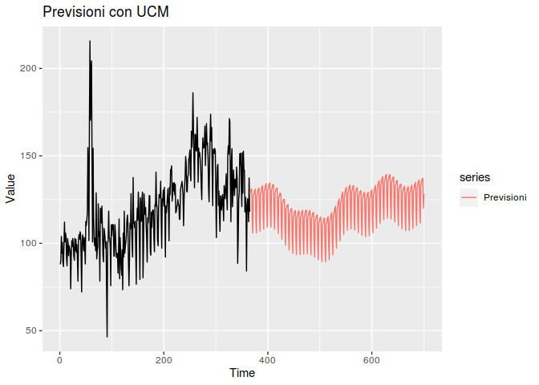

```r
pred_ucm <- predict(ucm_fit$model, n.ahead = 334)
autoplot(ts(y["2018-01-01/"]), main = "Previsioni con UCM") +
  autolayer(ts(pred_ucm, start = 366, end = 366+334), series = "Previsioni") +
  ylab("Value")
```

Viene infine creato il file csv con le previsioni di ARIMA e UCM, le previsioni della rete neurale verranno aggiunte in seguuito.

```r
final = data.frame(Data = seq(as.Date("2019-01-01"),
                              by = "day", length.out = 334),
                   ARIMA = pred_arima$mean, UCM = pred_ucm[,1])


write.csv(final, "SDMTSA_790032_0.csv", row.names = F)
```

Il grafico seguente mostra le previsioni delle tre metodologie sovrapposte, come ci si poteva aspettare dai risultati presentati in tabella, $ARIMA$ e $UCM$ producono un risultato molto simile, la $NN$ invece si discosta parecchio, probabilmente ciò è causato dall’ulteriore train effettuato sui dati di test.

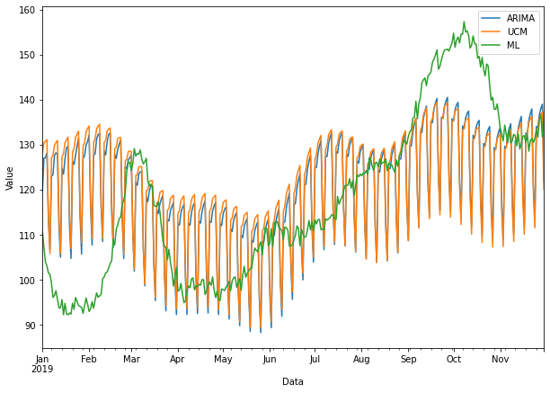

Previsioni delle tre metodologie